# *Lab #1*

This lab focuses on different statistical building blocks. Including continuous and discontiuous distributions.

```python
## Importing Libraries
%matplotlib inline
import numpy as np
import matplotlib
import matplotlib.pyplot as plt
import scipy
from scipy import stats
```

## A Little Statistics

### 1.

> 'sigma' = z = the probabibality that the background signal looks like desired signal.

### 1. A

The **Normal Distribution** is a symmetrical bell curve. The values of the mean, median, and mode are all equivalent. This happens when data has no right or left bias and is generally distributed around a central value.

A general normal distribution with $\mu = 0$ and $\sigma^2 = 1$ is called the **Standard Normal Distribuition.** Note that this sigma squared is completely different from the our Z value below.

### 1. B

Here we are using the cumulative density function (cdf) to integrate the standard normal distribution. In other words, we are using the cdf to integrate 'sigma' (z) and find a probability.

The normal distribution with a standard deviation $\sigma = 1$, and a mean $\mu = 0 $, is called the **Standard Normal Distribution**. This is represended by:

$$Z= \frac{X - \mu}{\sigma}$$

Where X is a random variable from a normal distribution, $\mu$ is the mean, and $\sigma$ is the standard deviation. Note again that the standard deviation $\sigma$ is different from our value of 'sigma' = Z.

The equation for the **Cumulative from mean (0 to z)** is f(z):

$$\phi (z) = \frac{1}{2\sqrt{\pi}} \int\limits_0^z e^{\frac{-x^2}{2}}dx = \frac{1}{2} erf(\frac{z}{\sqrt{2}}) $$$$f(z)= \phi (z) - \frac{1}{2}$$

The output of f(z) is the probability that a statistic is between 0 (the mean of the standard normal distribution) and Z ('sigma').

We will test three different Z values. Using the Cumulative from mean (0 to z) Z-table in Wikipedia, we can check that our input Z value coresponds to the correct probability output value.

```python
#Defining Variables
z = 0.01;
mu = 0;
sigma = 1;

#cumulative from mean function variable
cumulative_from_mean = stats.norm.cdf(z, mu, sigma) - 0.5

#prints input and output of cumulative from mean function
print("intput Z ('sigma') value = ", z)
print("output probability value = ", cumulative_from_mean)
```

```
intput Z ('sigma') value =  0.01
output probability value =  0.003989356314631598
```

```python
#2nd check with alternate value of z
z = 0.03;

#cumulative from mean function variable
cumulative_from_mean = stats.norm.cdf(z, mu, sigma) - 0.5

#prints input and output of cumulative from mean function
print("intput Z ('sigma') value = ", z)
print("output probability value = ", cumulative_from_mean)
```

```
intput Z ('sigma') value =  0.03
output probability value =  0.01196647341411261
```

```python
#3d check with alternate value of z
z = 0.22;

#cumulative from mean function variable
cumulative_from_mean = stats.norm.cdf(z, mu, sigma) - 0.5

#prints input and output of cumulative from mean function
print("intput Z ('sigma') value = ", z)
print("output probability value = ", cumulative_from_mean)
```

```
intput Z ('sigma') value =  0.22
output probability value =  0.08706442264821457
```

After checking the Cumulative from mean (0 to z) Z-table in Wikipedia, we see that our output probability values match the table.

### 1. C

Now we are taking the inverse of the cumulative distribution funciton. Given a probability value, we are determining the associated z ('sigma') value.

We do this using the **percent point function**. This function is the inverse of the cdf. When this function is given a probability input, it outputs the value z.

In other words, we are calculating the probability that the variable is less than or equal to z for a given z value.

Each output z (sigma) value for different input probabalities is checked for accuracy with the cumulative Z-table in Wikipedia. For negative values of z, you need to check the table from the bottom right hand corner, starting with the row first, then the column.

```python
#Define variables
z = 0.01;
mu = 0;
sigma = 1;

#define probability sigma
probability_input = stats.norm.cdf(z, mu, sigma)
print("Input probability value = ", probability_input);

ppf = stats.norm.ppf(probability_input);
print("Output z ('sigma') value = ", ppf);
```

```
Input probability value =  0.5039893563146316
Output z ('sigma') value =  0.009999999999999985
```

```python
#2nd Test with new probabability input
#Define variables
z = 0.4;
mu = 0;
sigma = 1;

#define probability sigma
probability_input = stats.norm.cdf(z, mu, sigma)
print("Input probability value = ", probability_input);

ppf = stats.norm.ppf(probability_input);
print("Output z ('sigma') value = ", ppf);
```

```
Input probability value =  0.6554217416103242
Output z ('sigma') value =  0.4000000000000001
```

```python
#3d Test with new probabability input
#Define variables
z = -0.01;
mu = 0;
sigma = 1;

#define probability sigma
probability_input = stats.norm.cdf(z, mu, sigma)
print("Input probability value = ", probability_input);

ppf = stats.norm.ppf(probability_input);
print("Output z ('sigma') value = ", ppf);
```

```
Input probability value =  0.4960106436853684
Output z ('sigma') value =  -0.009999999999999985
```

```python
#4th Test with new probabability input
#Define variables
z = -0.21;
mu = 0;
sigma = 1;

#define probability sigma
probability_input = stats.norm.cdf(z, mu, sigma)
print("Input probability value = ", probability_input);

ppf = stats.norm.ppf(probability_input);
print("Output z ('sigma') value = ", ppf);
```

```
Input probability value =  0.4168338365175577
Output z ('sigma') value =  -0.21000000000000002
```

After checking The Cumulative Z-table in wikipedia, we see that our input and output values match the table.

### 1. D

When z ('sigma') is negative, it has a different meaning depending on the context of the situation.

The Z ('sigma') helps us interpret the distribution values of the random continuous variable x. Z ('sigma') allows us to calculate the probability that a x variable vlaue is accuring within a distribution.

A negative value of Z means that the values of the distribution you are looking at of your data is below the mean of the distribution.

### 2. Exponential Distribution

Using an *exponential distribution*, we take ~100k samples and make both a histogram plot of data, and a histogram plot along with a probability density function overlay.

### 2. A

The **exponential distribtuion** is the probability distribution of a process where each data point represents an event that occurs independently and continuously at a constant average rate.

The random variable x is an exponential distribution with the rate parameter $\lambda$ as the constant of proportionality.

$$f(x) = e^{-\lambda x}$$

The cumulative distribution function (cdf) an exponential distribution is:

$$cdf(x) = 1 - e^{-\lambda x}$$

The probability density funciton (pdf) is:

$$pdf(x) = \lambda e^{-\lambda x}$$

#### 2. B

Make the same three plots as in home work 1.

**Plot 1**: A histogram of the exponential distribution of data, with a probability distribution function overlay (in orange).

**Plot 2**: A histogram of the exponential distribution of data with a log y-axis.

**Plot 3**: A histogram of the exponential distribution of data with a log y-axis, and a probability distribution funciton overlay (in orange).

```python
#Getting random exponential distribution of points
d = stats.expon.rvs(loc = 5., scale = 0.01, size = 100000);
```

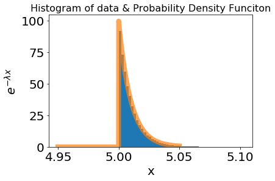

```python
#-----Plot 1------
#Histogram with Probability Density function -- plot 1
fig, ax = plt.subplots(1, 1)
ax.hist(d,50, density=True)
plt.tick_params(labelsize = 20)
#plt.xlim([4.95,5.05])
x = np.linspace(4.95,5.05,1000)
ax.plot(x,stats.expon.pdf(x,loc = 5., scale = 0.01),linewidth = 8,alpha = 0.7)

#Setting plot title and lables
ax.set_xlabel('x', size = 20)
ax.set_ylabel('$e^{-\lambda x}$', size = 20)
ax.set_title('Histogram of data & Probability Density Funciton', size = 16)

plt.show()
```

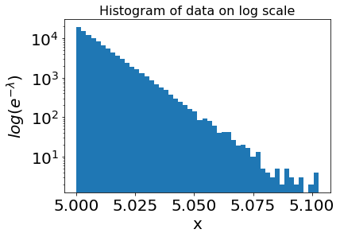

```python
#-----Plot 2-----
fig, ax = plt.subplots(1, 1)

ax = plt.hist(d,50)
plt.yscale('log')
plt.tick_params(labelsize = 20)
plt.xlabel('z')

#Setting plot title and lables
plt.xlabel('x', size = 20)
plt.ylabel('$log( e^{-\lambda} )$', size = 20)
plt.title('Histogram of data on log scale', size = 16)
plt.show()
```

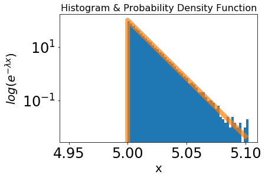

```python
#-----Plot 3-----
fig, ax = plt.subplots(1, 1)
ax.hist(d,50, density=True)
plt.yscale('log')
plt.tick_params(labelsize = 24)

#Setting plot title and lables
ax.set_xlabel('x', size = 20)
ax.set_ylabel('$log( e^{-\lambda x} )$', size = 20)
ax.set_title('Histogram & Probability Density Function', size = 16)

x = np.linspace(4.95,5.1,1000)
ax.plot(x,stats.expon.pdf(x,loc = 5., scale = 0.01),linewidth = 8,alpha = 0.7)
plt.show()
```

#### 3. Signal-free data - Exponential Distribution

Immagine that there is some signal-free data (background noise data) follows an exponential distribution.

#### 3. A

Value selected: My hypothetical measurement value is the probability that data points lay Z ('sigma') = 0.3 away from the mean.

#### 3. B

**Statistical question:** There is no signal, and the signal-free background noise data has an exponential distribution. What is the probability that the data produces a signal that is equally or more signal-like than the data observed?

I want to measure the probability that datapoints lay z = 0.3 away from the mean of my exponentially distributed data.

#### 3. C

**Convert word question into mathmatical integral:**

The **cumulative distribution function (cdf)** an exponential distribution is:

$$cdf(x) = 1 - e^{-\lambda x}$$

The **probability density funciton (pdf)** then is the derivative of the cdf:

$$pdf(x) = \lambda e^{-\lambda x}$$

Integrals of the probability density function give probabilities:

$$P(x) = \int\limits_{-\infty}^x pdf(x) dx = \int\limits_{-\infty}^x \lambda e^{-\lambda x} dx$$

#### 3. D

Calculate the probability that the backgroud produced the signal using the cdf for an exponential distribution.

```python
#Defining Variables
z = 0.3;
mu = 0;
sigma = 1;

#cumulative from mean function variable
cumulative_from_mean = stats.expon.cdf(z, mu, sigma)

#prints input and output of cumulative from mean function
print("intput: Z ('sigma') value = ", z)
print("output: probability that background produced signal = ", cumulative_from_mean)
```

```
intput: Z ('sigma') value =  0.3
output: probability that background produced signal =  0.2591817793182821
```

#### 3. E

Convert found probability into an equivalent Z ('sigma').

```python
#define probability sigma
probability_input = stats.expon.cdf(z, mu, sigma)
print("Input probability value = ", probability_input);

ppf = stats.expon.ppf(probability_input);
print("Output z ('sigma') value = ", ppf);
```

```
Input probability value =  0.2591817793182821
Output z ('sigma') value =  0.3
```

#### 3. E

After exploring with different hypothetical measurement values, there were different patterns that emerged in how the probabilities and coresponding Z ('sigmas') values changed.

After testing multiple different vlaues of Z ('sigma'), we see that negative values of Z corespond to zero probability. This is because in an exponential distribution, there is zero probability of finding data to the left of the mean of the distribution.

Increasing the value of Z increases the probability that you will find data points within the range from $-\infty$ to some point Z. This is because exponential functions often have a long tail that stretches out towards positive $\infty$.

## Non-continuous distributions

### 1. A

The **Binomial distribution** is a discrete probability distribution. Note "bi" means two. Out of n independent experients, each asking a yes or no question with a boolean true or false outcome, the Binomial distribution represents the probability distribution of the number of successes in a sequence.

There is no probability density function for a binomial distribution, because it is discontinuous, so instead we have a probability mass function.

The general binomial **probability mass function**, for the probability of k out of n ways is:

$$f(k,n,p) = \binom{n}{k} \cdot p^k(1-p)^{n-k}$$

- P is a continuous probability value between 0 and 1, the success probability for each trial
- k is the individual trial k = 0, 1, 2, ... n.
- n is the total number of trials

### 1. B

Below are a series of histogram plots of binomial distributions.

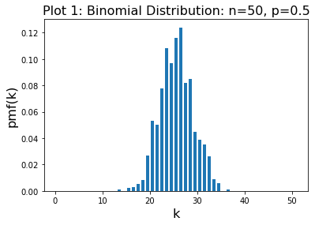

```python
#---Plot 1---
n_total = 50

#making random binomial distibution
binomial=stats.binom(n_total,p=0.5)

#Generates a discrete set of numbers from zero to ten
n=np.arange(0,n_total+1)


#Samples 1000 random numbers from of a binomial create histogram
binomial_sample=binomial.rvs(size=1000, random_state=143)

plt.hist(binomial_sample,bins=len(n),range=(0,len(n)),density=True, rwidth=0.75)
plt.title("Plot 1: Binomial Distribution: n=50, p=0.5", size = 16)
plt.ylabel("pmf(k)", size = 16)
plt.xlabel("k", size = 16)
#plt.xticks(n)
plt.show()
```

In plot 1 above, we can see that with a 0.5 probability of success rate for each trial, the gaussian distribution centered at right near 25. Notice that 25 = 50/2 = n*(0.5).

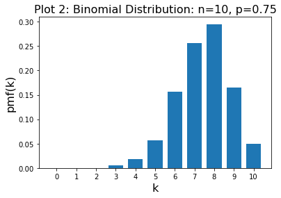

```python
#---Plot 2----
n_total = 10

#making random binomial distibution
binomial=stats.binom(n_total,p=0.75)

#Generates a discrete set of numbers from zero to ten
n=np.arange(0,n_total+1)

#Graph with histogram and histogram together
binomial_sample=binomial.rvs(size=1000)
plt.hist(binomial_sample,bins=len(n),range=(0,len(n)),density=True,align='left',rwidth=0.75)
plt.title("Plot 2: Binomial Distribution: n=10, p=0.75", size = 16)
plt.ylabel("pmf(k)", size = 16)
plt.xlabel("k", size = 16)
plt.xticks(n)
plt.show()
```

In plot 2 above, we can see that when the success rate is higher (p=0.75), it shifts the distribution to the right

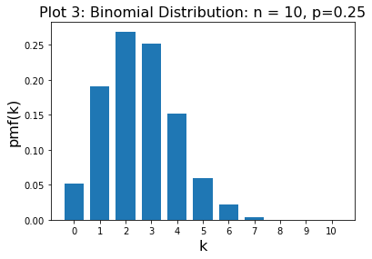

```python
#---Plot 3---
n_total = 10

#making random binomial distibution
binomial=stats.binom(n_total,p=0.25)

#Generates a discrete set of numbers from zero to ten
n=np.arange(0,n_total+1)

#Graph with histogram and histogram together
binomial_sample=binomial.rvs(size=1000)
plt.hist(binomial_sample,bins=len(n),range=(0,len(n)),density=True,align='left',rwidth=0.75)
plt.title("Plot 3: Binomial Distribution: n = 10, p=0.25", size = 16)
plt.ylabel("pmf(k)", size = 16)
plt.xlabel("k", size = 16)
plt.xticks(n)
plt.show()
```

After changing different parameters, and multiple tests, it seems as if the distribution is always a gaussian shape with a center at about (n*p).

### 1. C

**Define hypothetical question:**

From plot 3, what is the probability of getting the most successes for after 1 trial?

```python
k_input = 1
print("Input k value = ", k_input);

probability = binomial.pmf(k_input);
print("oputput pmf value = ", probability);
```

```
Input k value =  1
oputput pmf value =  0.18771171569824247
```

From the graph above, we can see that the output value is correct.

### 1. E

*Explain why it makes sense that the relsults are discrete and but the parameters of the distributions are not:*

- The input probability p, is the probability of success for any individual trial. This is a continuous variable that can have any value between 0 or 1.
- The results of the pmf are discontinuous because the data is discontinuous. Each data point will have a boolean outcome, either true or false, for a specific number of trials. The number of trials is also a discontinuous number. Because the data points are discrete, not continuous, the results of the pmf to also discrete.
- When looking at the overall data, it is possible to have an average mean with a non-integer value, like 5.5, however, the actuall data points come from a discontinuous distribtuion.